# Reproducible Research

Set the working directory and read in the data

```r
wd <- getwd()
current_proj_dir  <- "/Reproducible Research/RepData_PeerAssessment1"
wd1 <- paste0(wd, "/activity/activity.csv")
activity <- read.csv(wd1)
```

Check some stats about the data

```r
head(activity)
```

```
##   steps       date interval
## 1    NA 2012-10-01        0
## 2    NA 2012-10-01        5
## 3    NA 2012-10-01       10
## 4    NA 2012-10-01       15
## 5    NA 2012-10-01       20
## 6    NA 2012-10-01       25
```

```r
str(activity)
```

```
## 'data.frame':    17568 obs. of  3 variables:
##  $ steps   : int  NA NA NA NA NA NA NA NA NA NA ...
##  $ date    : Factor w/ 61 levels "2012-10-01","2012-10-02",..: 1 1 1 1 1 1 1 1 1 1 ...
##  $ interval: int  0 5 10 15 20 25 30 35 40 45 ...
```

```r
names(activity)
```

```
## [1] "steps"    "date"     "interval"
```

Convert dates to date objects

```r
library(lubridate)
activity$date <- ymd(activity$date)
str(activity)
```

```
## 'data.frame':    17568 obs. of  3 variables:
##  $ steps   : int  NA NA NA NA NA NA NA NA NA NA ...
##  $ date    : Date, format: "2012-10-01" "2012-10-01" ...
##  $ interval: int  0 5 10 15 20 25 30 35 40 45 ...
```

```r
head(activity)
```

```
##   steps       date interval
## 1    NA 2012-10-01        0
## 2    NA 2012-10-01        5
## 3    NA 2012-10-01       10
## 4    NA 2012-10-01       15
## 5    NA 2012-10-01       20
## 6    NA 2012-10-01       25
```

Calculate the total number of steps taken per day

```r
ttl_walks_by_day <- aggregate(activity["steps"], by=list(Date=activity$date), FUN=sum)
ttl_walks_by_day
```

```
##          Date steps
## 1  2012-10-01    NA
## 2  2012-10-02   126
## 3  2012-10-03 11352
## 4  2012-10-04 12116
## 5  2012-10-05 13294
## 6  2012-10-06 15420
## 7  2012-10-07 11015
## 8  2012-10-08    NA
## 9  2012-10-09 12811
## 10 2012-10-10  9900
## 11 2012-10-11 10304
## 12 2012-10-12 17382
## 13 2012-10-13 12426
## 14 2012-10-14 15098
```

[output cut: 47 more lines]

Make a histogram of the total number of steps taken each day

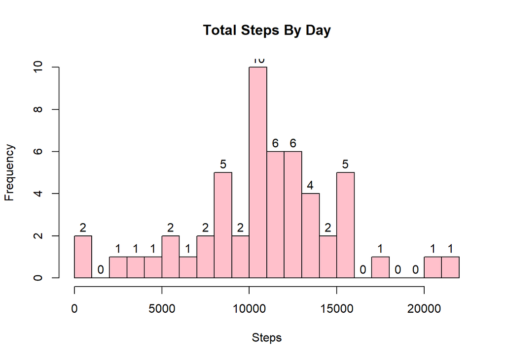

```r
hist(ttl_walks_by_day$steps
        , breaks = 20
        , col = "pink"
        , main = "Total Steps By Day"
        ,xlab = "Steps"
        ,labels = TRUE)
```

```r
daily_mean <- aggregate(activity["steps"], by=list(Date=activity$date), FUN=mean)
daily_mean
```

```
##          Date      steps
## 1  2012-10-01         NA
## 2  2012-10-02  0.4375000
## 3  2012-10-03 39.4166667
## 4  2012-10-04 42.0694444
## 5  2012-10-05 46.1597222
## 6  2012-10-06 53.5416667
## 7  2012-10-07 38.2465278
## 8  2012-10-08         NA
## 9  2012-10-09 44.4826389
## 10 2012-10-10 34.3750000
## 11 2012-10-11 35.7777778
## 12 2012-10-12 60.3541667
## 13 2012-10-13 43.1458333
## 14 2012-10-14 52.4236111
```

[output cut: 47 more lines]

```r
daily_median <- aggregate(activity["steps"], by=list(Date=activity$date), FUN=median)
daily_median
```

```
##          Date steps
## 1  2012-10-01    NA
## 2  2012-10-02     0
## 3  2012-10-03     0
## 4  2012-10-04     0
## 5  2012-10-05     0
## 6  2012-10-06     0
## 7  2012-10-07     0
## 8  2012-10-08    NA
## 9  2012-10-09     0
## 10 2012-10-10     0
## 11 2012-10-11     0
## 12 2012-10-12     0
## 13 2012-10-13     0
## 14 2012-10-14     0
```

[output cut: 47 more lines]

1. Make a time series plot (i.e. type = “l”) of the 5-minute interval (x-axis) and the average number of steps taken, averaged across all days (y-axis)

```r
library(dplyr)
```

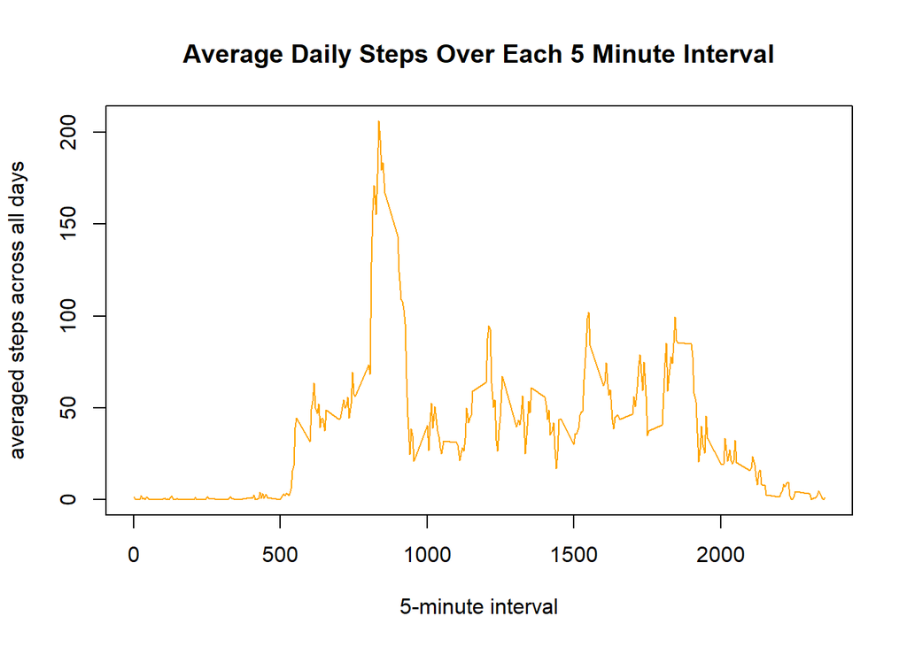

```r
activity_new <- activity %>%
            group_by(interval) %>%
            summarise(AvgSteps = mean(steps, na.rm = TRUE))

plot(activity_new,
    type ="l",
    xlab= "5-minute interval",
    ylab="averaged steps across all days",
    main ="Average Daily Steps Over Each 5 Minute Interval",
    col = "orange")
```

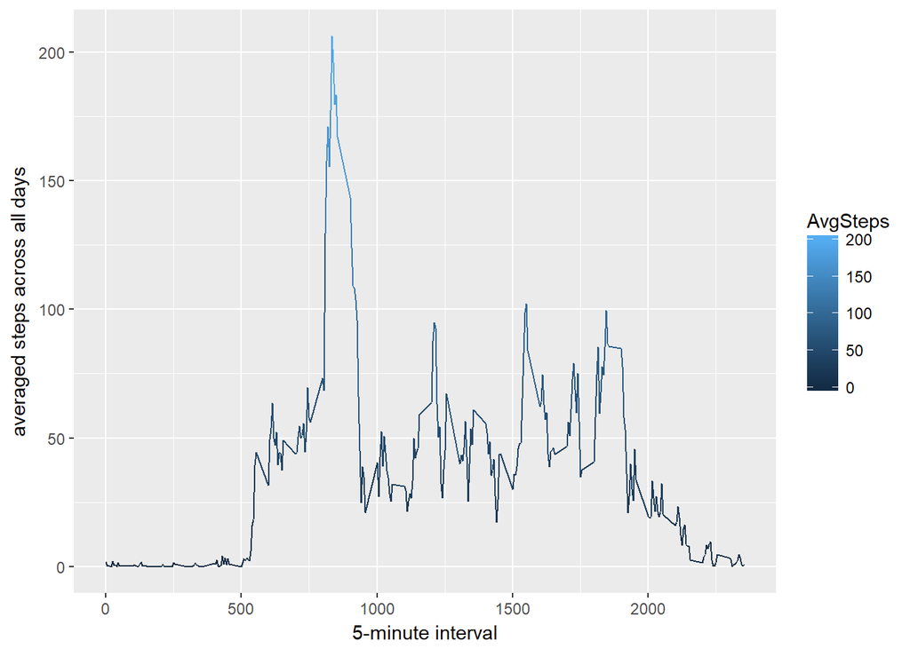

```r
library(ggplot2)
ggplot(activity_new, aes(interval, AvgSteps,col = AvgSteps)) + geom_line() +
            xlab("5-minute interval") + ylab("averaged steps across all days")
```

check if there are all NAs

```r
sum(!is.na(activity_new$AvgSteps))
```

```
## [1] 288
```

2. which interval on average contains the maximum number of steps

```r
activity_new$interval[which.max(activity_new$AvgSteps)]
```

```
## [1] 835
```

### Imputing missing values

impute MISSING VALUES with the interval average steps

```r
activity_imputed <- activity %>%
    group_by(interval) %>%
    mutate(AvgSteps = ifelse( is.na(steps), mean(steps, na.rm = TRUE), steps))


#check if there are any NAs in the average
sum(is.na(activity_imputed$AvgSteps))
```

```
## [1] 0
```

4a. Calculate the total number of steps taken per day Make a histogram of the total number of steps taken each day

```r
activity_imputed_ttl_daily_steps <- aggregate(activity_imputed["AvgSteps"], by=list(Date=activity_imputed$date), FUN=sum)
activity_imputed_ttl_daily_steps
```

```
##          Date AvgSteps
## 1  2012-10-01 10766.19
## 2  2012-10-02   126.00
## 3  2012-10-03 11352.00
## 4  2012-10-04 12116.00
## 5  2012-10-05 13294.00
## 6  2012-10-06 15420.00
## 7  2012-10-07 11015.00
## 8  2012-10-08 10766.19
## 9  2012-10-09 12811.00
## 10 2012-10-10  9900.00
## 11 2012-10-11 10304.00
## 12 2012-10-12 17382.00
## 13 2012-10-13 12426.00
## 14 2012-10-14 15098.00
```

[output cut: 47 more lines]

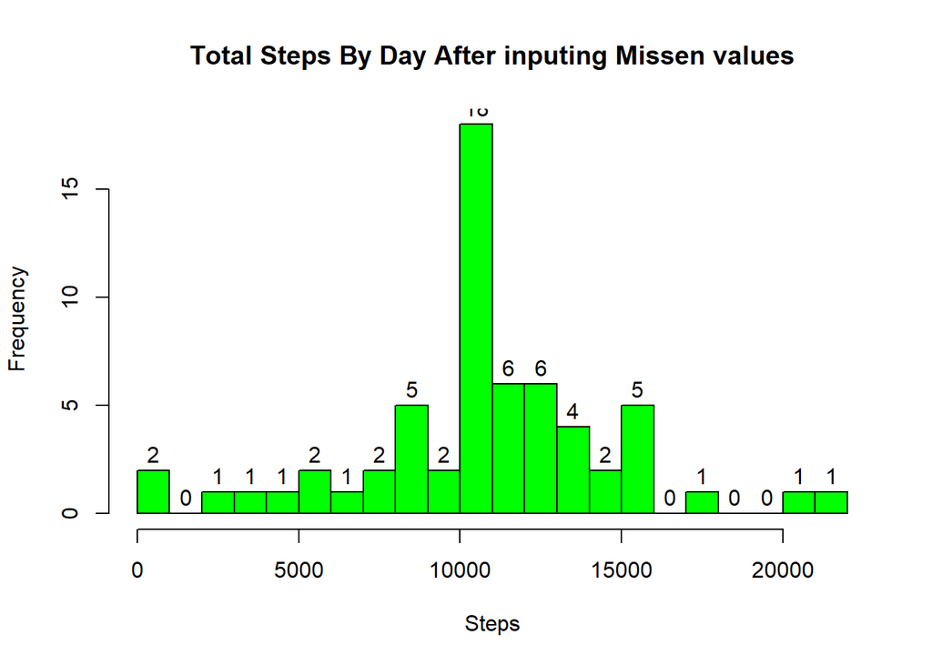

```r
#4bhistory gram
hist(activity_imputed_ttl_daily_steps$AvgSteps,
        breaks = 20,
        col="green",
        main = "Total Steps By Day After inputing Missen values",
        xlab = "Steps",
        labels = T)
```

```r
daily_mean_after_imputation <- aggregate(activity_imputed["AvgSteps"], by=list(Date=activity_imputed$date), FUN=mean)
daily_mean_after_imputation
```

```
##          Date   AvgSteps
## 1  2012-10-01 37.3825996
## 2  2012-10-02  0.4375000
## 3  2012-10-03 39.4166667
## 4  2012-10-04 42.0694444
## 5  2012-10-05 46.1597222
## 6  2012-10-06 53.5416667
## 7  2012-10-07 38.2465278
## 8  2012-10-08 37.3825996
## 9  2012-10-09 44.4826389
## 10 2012-10-10 34.3750000
## 11 2012-10-11 35.7777778
## 12 2012-10-12 60.3541667
## 13 2012-10-13 43.1458333
## 14 2012-10-14 52.4236111
```

[output cut: 47 more lines]

### 4cii median

```r
daily_median_imputation <- aggregate(activity_imputed["AvgSteps"], by=list(Date=activity_imputed$date), FUN=median)
daily_median_imputation
```

```
##          Date AvgSteps
## 1  2012-10-01 34.11321
## 2  2012-10-02  0.00000
## 3  2012-10-03  0.00000
## 4  2012-10-04  0.00000
## 5  2012-10-05  0.00000
## 6  2012-10-06  0.00000
## 7  2012-10-07  0.00000
## 8  2012-10-08 34.11321
## 9  2012-10-09  0.00000
## 10 2012-10-10  0.00000
## 11 2012-10-11  0.00000
## 12 2012-10-12  0.00000
## 13 2012-10-13  0.00000
## 14 2012-10-14  0.00000
```

[output cut: 47 more lines]

### Do these values differ from the estimates from the first part of the assignment?

ANS: yes, they do, the missen values are well filled out which impacts the distribution of the steps

### What is the impact of imputing missing data on the estimates of the total daily number of steps?

ANS: it makes it more clear that on average more steps were taken which counted around between 10000 and 15000

### 5 Are there differences in activity patterns between weekdays and weekends?

```r
activity_imputed_wkdays <- activity_imputed %>%
     mutate(wkday =  as.factor(ifelse( weekdays(date) %in% c("Saturday", "Sunday"), "weekend","weekday")))


table(activity_imputed$wkday)
```

```
## < table of extent 0 >
```

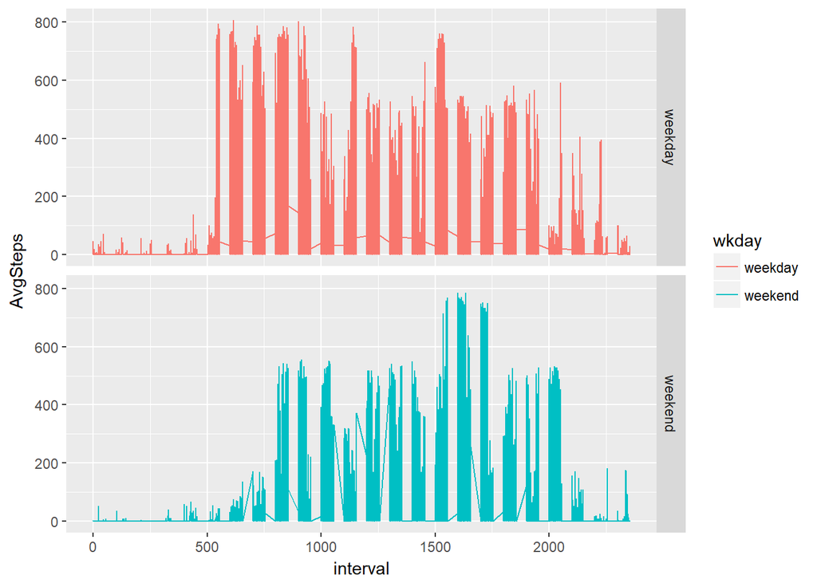

```r
g <- ggplot(data = activity_imputed_wkdays, aes(x= interval, y=AvgSteps, col = wkday) ) + geom_line()
g + facet_grid(wkday ~ .)
```